# Data Mining Assignment 1

Ryan Weisner

10/6/2019

# Prompt

*A restaurant owner has a core menu that has remained constant throughout the past two years, while many other dishes have rotated on and off the menu. The owner has prepared a dataset of all orders containing elements of that core menu in which the customer also ordered wine. The dataset has 3 columns: orderNumber which identiﬁes each individual person’s order at a table, order which itemizes the order’s components, and type which provides the type of item in the order (takes one of 3 values: ‘Meat’, ‘Side’, ‘Wine’).*

*The restaurant owner would like to add wine suggestions to the menu next to each meat and analyze her customer ordering habits in general. She is also interested in showing a picture of a popular meal of hers in an ad in Gourmet Diner magazine . Your job is to address her interests and also to report anything else of interest in terms of customer ordering habits, all in a nice summary report that is complete but to the point.*

Load and inspect the data.

```r
setwd("C:/Users/ryanjw/MSA_All/Data Mining")
restaurantdf<- read.csv("restaurantData.csv", sep = ",", header = TRUE)
head(restaurantdf)
```

|  | order | type | orderNumber |
| --- | --- | --- | --- |
| 1 | Mashed Potatoes | Side | 14 |
| 2 | Filet Mignon | Meat | 14 |
| 3 | Blackstone Merlot | Wine | 14 |
| 4 | Mashed Potatoes | Side | 22 |
| 5 | Pork Tenderloin | Meat | 22 |
| 6 | Cantina Pinot Bianco | Wine | 22 |

The data is in ‘single’ format (i.e, long) instead of ‘basket’ format (i.e., wide), because each `orderNumber` appears for each corresponding value of `order`. (If it was in ‘basket’ format, each `orderNumber` would appear once and each value of its `order` would be in the same row .)

So, with `arules` we need to load it as `format = "single"`.

```r
setwd("C:/Users/ryanjw/MSA_All/Data Mining")
restaurant <- read.transactions("restaurantData.csv", sep = ",", header = TRUE, format = "single",
                                cols = c(3,1))
summary(restaurant)
```

```
## transactions as itemMatrix in sparse format with
##  8499 rows (elements/itemsets/transactions) and
##  14 columns (items) and a density of 0.2183618
##
## most frequent items:
##      Pork Tenderloin Cantina Pinot Bianco  Duckhorn Chardonnay
##                 4786                 4699                 2483
##     Roasted Root Veg Steamed Seasonal Veg              (Other)
##                 2177                 2039                 9798
##
## element (itemset/transaction) length distribution:
## sizes
##    3    4    5    6
## 8218   79  200    2
##
##    Min. 1st Qu.  Median    Mean 3rd Qu.    Max.
##   3.000   3.000   3.000   3.057   3.000   6.000
##
## includes extended item information - examples:
##              labels
## 1       Baked Beans
## 2 Blackstone Merlot
## 3      Caesar Salad
##
## includes extended transaction information - examples:
##   transactionID
## 1         10004
## 2         10023
## 3         10025
```

```r
inspect(restaurant[1:5])
```

```
##     items                  transactionID
## [1] {Cantina Pinot Bianco,
##      Pork Tenderloin,
##      Roasted Root Veg}             10004
## [2] {Cantina Pinot Bianco,
##      Pork Tenderloin,
##      Roasted Root Veg}             10023
## [3] {Cantina Pinot Bianco,
##      Pork Tenderloin,
##      Roasted Root Veg}             10025
## [4] {Cantina Pinot Bianco,
##      Pork Tenderloin,
##      Roasted Root Veg}             10040
## [5] {Blackstone Merlot,
##      Pork Tenderloin,
##      Roasted Root Veg}             10049
```

Visualize the data.

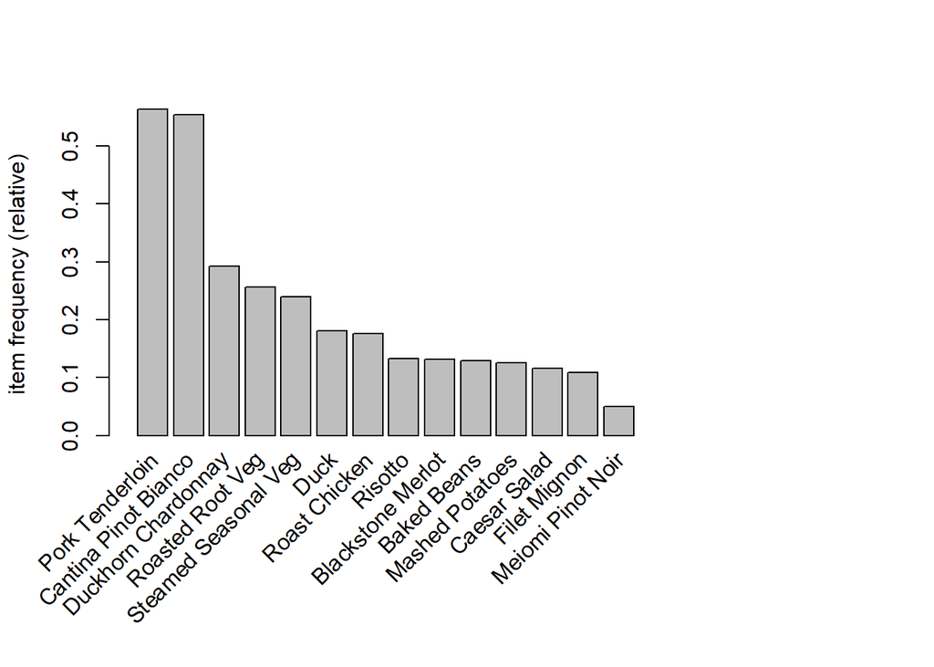

```r
itemFrequencyPlot(restaurant, topN = 20)
```

Uncover rules in the data.

```r
rules <- apriori(restaurant, parameter = list(support = 0.006, confidence = 0.25, minlen = 2))
siderules <- subset(rules, items %in% c("Baked Beans", "Caesar Salad", "Mashed Potatoes",
                                        "Risotto", "Roasted Root Veg", "Steamed Seasonal Veg"))
meatrules <- subset(rules, items %in% c("Duck", "Filet Mignon", "Pork Tenderloin", "Roast Chicken"))
winerules <- subset(rules, items %in% c("Blackstone Merlot", "Cantina Pinot Bianco",
                                        "Duckhorn Chardonnay", "Meiomi Pinot Noir"))
meatwinerules <- subset(rules, rhs %in% c("Blackstone Merlot", "Cantina Pinot Bianco",
                                        "Duckhorn Chardonnay", "Meiomi Pinot Noir") &
                          lhs %in% c("Duck", "Filet Mignon", "Pork Tenderloin", "Roast Chicken"))
```

# Wine pairing

List the rules, sorted by descending “lift”.

```r
inspect(sort(meatwinerules, by = "lift"))
```

```
##      lhs                       rhs                        support confidence      lift count
## [1]  {Filet Mignon,
##       Roasted Root Veg}     => {Blackstone Merlot}    0.025061772  0.8623482 6.5263554   213
## [2]  {Filet Mignon,
##       Steamed Seasonal Veg} => {Blackstone Merlot}    0.022708554  0.8354978 6.3231488   193
## [3]  {Filet Mignon,
##       Risotto}              => {Blackstone Merlot}    0.012472056  0.8281250 6.2673503   106
## [4]  {Filet Mignon}         => {Blackstone Merlot}    0.090245911  0.8256189 6.2483842   767
## [5]  {Filet Mignon,
##       Mashed Potatoes}      => {Blackstone Merlot}    0.010942464  0.8157895 6.1739935    93
## [6]  {Caesar Salad,
##       Filet Mignon}         => {Blackstone Merlot}    0.009883516  0.8155340 6.1720599    84
## [7]  {Baked Beans,
##       Filet Mignon}         => {Blackstone Merlot}    0.009177550  0.7358491 5.5689948    78
## [8]  {Roast Chicken,
##       Roasted Root Veg}     => {Duckhorn Chardonnay}  0.037298506  0.8342105 2.8553988   317
## [9]  {Roast Chicken,
##       Steamed Seasonal Veg} => {Duckhorn Chardonnay}  0.037298506  0.8170103 2.7965246   317
## [10] {Duck,
##       Risotto}              => {Duckhorn Chardonnay}  0.020825980  0.8119266 2.7791237   177
## [11] {Pork Tenderloin,
##       Roast Chicken}        => {Duckhorn Chardonnay}  0.007294976  0.8051948 2.7560816    62
## [12] {Roast Chicken}        => {Duckhorn Chardonnay}  0.141428403  0.8024032 2.7465263  1202
## [13] {Caesar Salad,
##       Roast Chicken}        => {Duckhorn Chardonnay}  0.016590187  0.8011364 2.7421901   141
## [14] {Cantina Pinot Bianco,
##       Pork Tenderloin,
##       Roast Chicken}        => {Duckhorn Chardonnay}  0.006471350  0.7971014 2.7283791    55
## [15] {Baked Beans,
##       Roast Chicken}        => {Duckhorn Chardonnay}  0.017178492  0.7891892 2.7012964   146
## [16] {Risotto,
##       Roast Chicken}        => {Duckhorn Chardonnay}  0.017296152  0.7736842 2.6482248   147
## [17] {Mashed Potatoes,
##       Roast Chicken}        => {Duckhorn Chardonnay}  0.015766561  0.7486034 2.5623761   134
## [18] {Duck}                 => {Duckhorn Chardonnay}  0.129779974  0.7190352 2.4611680  1103
## [19] {Duck,
##       Roasted Root Veg}     => {Duckhorn Chardonnay}  0.032945052  0.7179487 2.4574491   280
## [20] {Duck,
##       Mashed Potatoes}      => {Duckhorn Chardonnay}  0.018119779  0.7096774 2.4291375   154
## [21] {Duck,
```

[output cut: 14 more lines]

```
## [29] {Pork Tenderloin,
##       Roasted Root Veg}     => {Cantina Pinot Bianco} 0.133427462  0.9242054 1.6715943  1134
## [30] {Caesar Salad,
##       Pork Tenderloin}      => {Cantina Pinot Bianco} 0.061654312  0.9225352 1.6685735   524
## [31] {Pork Tenderloin,
##       Steamed Seasonal Veg} => {Cantina Pinot Bianco} 0.123896929  0.9156522 1.6561242  1053
## [32] {Pork Tenderloin,
##       Roast Chicken}        => {Cantina Pinot Bianco} 0.008118602  0.8961039 1.6207676    69
## [33] {Duckhorn Chardonnay,
##       Pork Tenderloin,
##       Roast Chicken}        => {Cantina Pinot Bianco} 0.006471350  0.8870968 1.6044766    55
## [34] {Cantina Pinot Bianco,
##       Roast Chicken}        => {Duckhorn Chardonnay}  0.007177315  0.4357143 1.4913958    61
## [35] {Duckhorn Chardonnay,
##       Pork Tenderloin}      => {Cantina Pinot Bianco} 0.012707377  0.3843416 0.6951521   108
```

We should recommend wine pairings based on the meats that have the highest lift. For example, when recommending a wine for `Filet Mignon`, we should recommend `Blackstone Merlot` because those who ordered `Filet Mignon` were 6.25 times more likely to order `Blackstone Merlot` than the overall cutsomer base. This suggests that this is the most popular pairing.

# Most popular meal to recommend for the ad

```r
inspect(sort(meatwinerules, by = "count")[1:10])
```

```
##      lhs                       rhs                       support confidence     lift count
## [1]  {Pork Tenderloin}      => {Cantina Pinot Bianco} 0.52159078  0.9262432 1.675280  4433
## [2]  {Roast Chicken}        => {Duckhorn Chardonnay}  0.14142840  0.8024032 2.746526  1202
## [3]  {Pork Tenderloin,
##       Roasted Root Veg}     => {Cantina Pinot Bianco} 0.13342746  0.9242054 1.671594  1134
## [4]  {Duck}                 => {Duckhorn Chardonnay}  0.12977997  0.7190352 2.461168  1103
## [5]  {Pork Tenderloin,
##       Steamed Seasonal Veg} => {Cantina Pinot Bianco} 0.12389693  0.9156522 1.656124  1053
## [6]  {Filet Mignon}         => {Blackstone Merlot}    0.09024591  0.8256189 6.248384   767
## [7]  {Baked Beans,
##       Pork Tenderloin}      => {Cantina Pinot Bianco} 0.06883163  0.9375000 1.695640   585
## [8]  {Pork Tenderloin,
##       Risotto}              => {Cantina Pinot Bianco} 0.06836098  0.9310897 1.684046   581
## [9]  {Mashed Potatoes,
##       Pork Tenderloin}      => {Cantina Pinot Bianco} 0.06565478  0.9378151 1.696210   558
## [10] {Caesar Salad,
##       Pork Tenderloin}      => {Cantina Pinot Bianco} 0.06165431  0.9225352 1.668573   524
```

Looking only at full meals (i.e., those that include a meat, side, and wine), we can see that index `[3]` has the highest count of 1134. Given that the restaurant owner “is interested in showing a picture of a popular meal of hers in an ad in Gourmet Diner magazine”, we should recommend including `Pork Tenderloin`, `Roasted Root Veg`, and `Cantina Pino Biano`.